Let's convert the roots of a quadratic polynomial to a fixed point problem.

```matlab
f = @(x) x.^2 - 4*x + 3.5;
r = roots([1 -4 3.5])
```

r =

2.7071e+00 1.2929e+00

We'll define . Intersections of its graph with the line are fixed points of g and thus roots of f. (Only one is shown in the chosen plot range.)

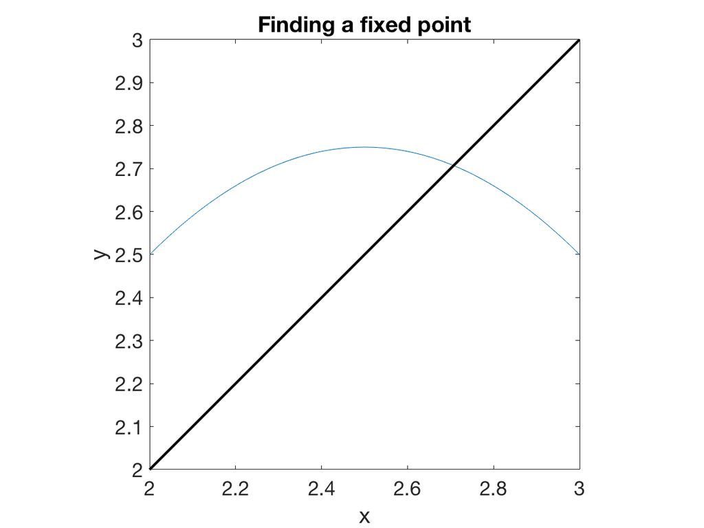

```matlab
g = @(x) x - f(x);
fplot(g,[2 3])
hold on, plot([2 3],[2 3],'k')
title('Finding a fixed point'), axis equal    % ignore this line
xlabel('x'), ylabel('y')    % ignore this line
```

If we evalaute , we get a value of almost 2.6.

```matlab
x = 2.1;  y = g(x)
```

y =

2.5900e+00

So is considerably closer to a fixed point than x was. The value ought to become our new x value! Changing the x coordinate in this way is the same as following a horizontal line over to the graph of .

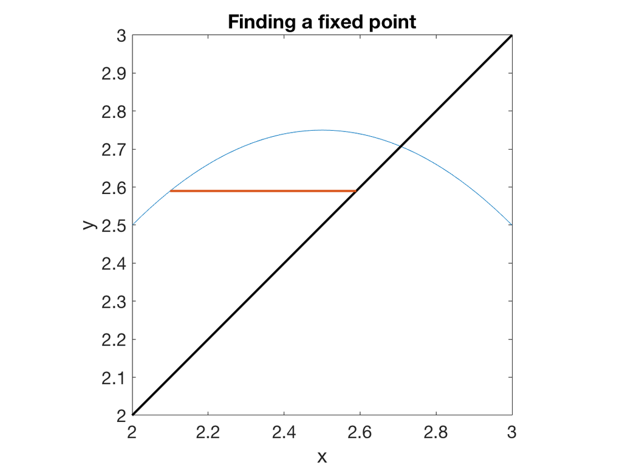

```matlab
plot([x y],[y y],'-')
```

```matlab
x = y;
```

Now we can compute a new value for y. We leave x alone here, so we travel along a vertical line to the graph of g.

```matlab
y = g(x)
```

y =

2.7419e+00

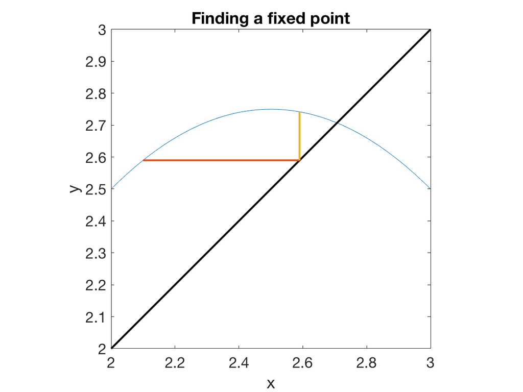

```matlab
plot([x x],[x y],'-')
```

You see that we are in a position to repeat these steps as often as we like. Let's apply them a few times and see the result.

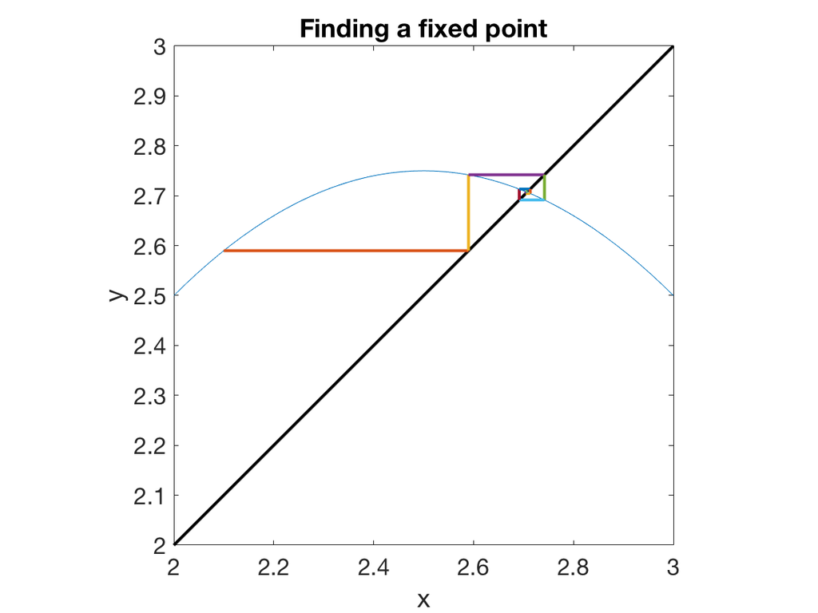

```matlab
for k = 1:5
    plot([x y],[y y],'-'),  x = y;    % y --> new x
    y = g(x);  plot([x x],[x y],'-')  % g(x) --> new y
end
```

The process spirals in beautifully toward the fixed point we seek. Our last estimate has almost 4 accurate digits.

```matlab
abs(y-r(1))/r(1)
```

ans =

1.6531e-04

Now let's try to find the other fixed point in the same way. We'll use 1.3 as a starting approximation.

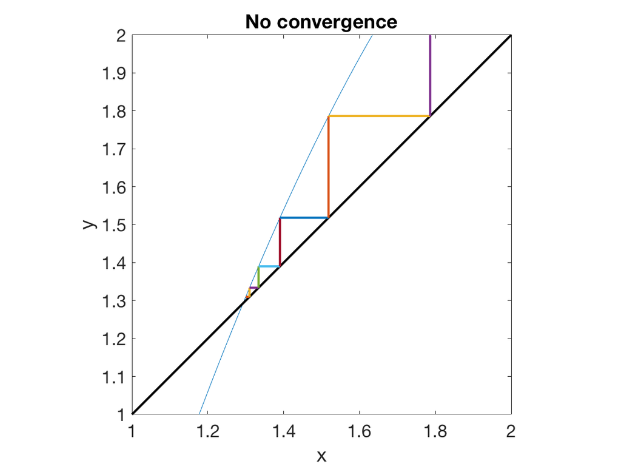

```matlab
cla
fplot(g,[1 2])
hold on, plot([1 2],[1 2],'k'), ylim([1 2])
x = 1.3; y = g(x);
for k = 1:5
    plot([x y],[y y],'-'),  x = y;    % y --> new x
    y = g(x);  plot([x x],[x y],'-')  % g(x) --> new y
end
title('No convergence')    % ignore this line
```

We started near the true fixed point, which is at about 1.293. But this time, the iteration is pushing us away from the correct answer.